# Desmid Mini Project - Data Analysis

Kristine Gesulga, Luisa Listmann, Klaus von Schwartzenberg, Elisa Schaum

Last updated: 2024-05-13

# 1 Meso community

## 1.1 ANOVA

### 1.1.1 Maximum growth rate

*Question a: Does temperature and/or nutrients have a significant effect on maximum growth rate (mumax)?*  
*Question b: Do temperature and nutrients have an interactive effect?*

**Click for details on tidying data.**

```r
dat_meso <- growth_params_lag %>%
  filter(community == "meso") %>%
  select(mumax, Temp, Nutrient)
glimpse(dat_meso) # response variable = mumax; explanatory variable = temperature / nutrient
```

```
## Rows: 18
## Columns: 3
## $ mumax    <dbl> 0.1165604, 0.1358292, 0.2572377, 0.1296799, 0.2225792, 0.1629…
## $ Temp     <chr> "18", "18", "18", "22", "22", "22", "18", "18", "18", "22", "…
## $ Nutrient <chr> "WHM", "WHM", "WHM", "WHM", "WHM", "WHM", "WHM_5N", "WHM_5N",…
```

```r
# Convert Temperature + Nutrient treatments to factors (ANOVA test likes it in this format)
dat_meso$Temp <- as.factor(dat_meso$Temp)
dat_meso$Nutrient <- as.factor(dat_meso$Nutrient)
# Sanity check
table(dat_meso$Temp, dat_meso$Nutrient)
```

```
##
##      WHM WHM_5N WHM_5P
##   18   3      3      3
##   22   3      3      3
```

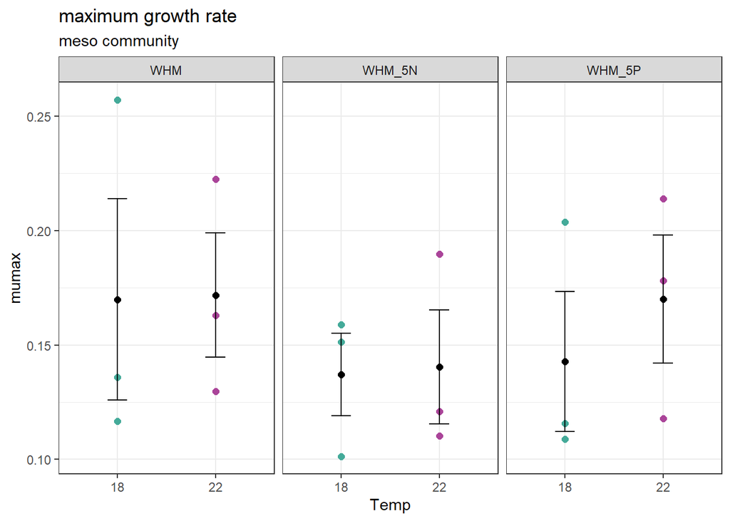

```r
growth_params_lag %>%
  filter(community == "meso") %>%
ggplot(aes(x = Temp, y = mumax, color = Temp)) +
  geom_point(size=2)+
  stat_summary(fun=mean,
               geom="point",
               show.legend = T,
               cex=2, color="black")+
  stat_summary(fun.data=mean_se,
               geom="errorbar",
               show.legend = F,
               width=0.2,
               cex=0.5, color="black")+
  labs(title="maximum growth rate",
       subtitle = "meso community",
       cex=1)+
  facet_wrap(~Nutrient) +
  theme_bw() +
  theme(legend.position = "none") +
  scale_color_manual(values = c("#44AA99", "#AA4499"))
```

**Click for details on model fitting, AICc test, and anova assumptions.**

**Fit model**

```r
# Additive model
meso_model_add <- lm(mumax ~ Temp + Nutrient, data = dat_meso)
meso_model_add
```

```
##
## Call:
## lm(formula = mumax ~ Temp + Nutrient, data = dat_meso)
##
## Coefficients:
##    (Intercept)          Temp22  NutrientWHM_5N  NutrientWHM_5P
##        0.16542         0.01077        -0.03205        -0.01444
```

```r
# Interactive model
meso_model_interx <- lm(mumax ~ Temp*Nutrient, data = dat_meso)
meso_model_interx
```

```
##
## Call:
## lm(formula = mumax ~ Temp * Nutrient, data = dat_meso)
##
## Coefficients:
##           (Intercept)                 Temp22         NutrientWHM_5N
##              0.169876               0.001867              -0.032697
##        NutrientWHM_5P  Temp22:NutrientWHM_5N  Temp22:NutrientWHM_5P
##             -0.027145               0.001303               0.025413
```

**Test AICc**

```r
models <- list(meso_model_add, meso_model_interx)
model.names <- c("meso_model_add", "meso_model_interx")

aictab(cand.set = models, modnames = model.names)
```

```
##
## Model selection based on AICc:
##
##                   K   AICc Delta_AICc AICcWt Cum.Wt    LL
## meso_model_add    5 -47.54       0.00   0.99   0.99 31.27
## meso_model_interx 7 -37.68       9.86   0.01   1.00 31.44
```

*Based on AICc test, the additive model is a better fit.*

**Check assumptions of interactive model**

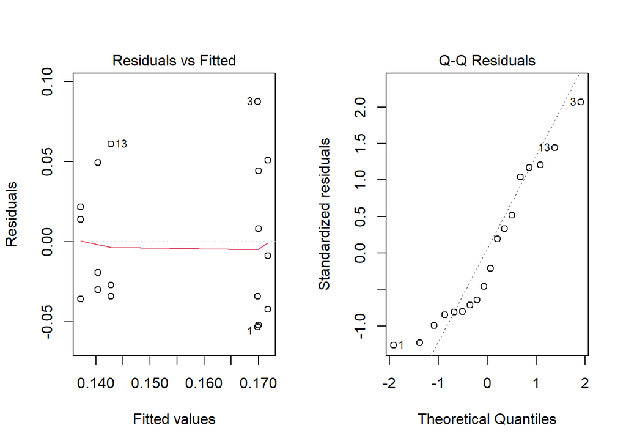

```r
# 1. Residuals-Fit plot check that variance is constant across groups
# --> Want: straight line; Avoid: funnel-like shape
# 2. QQ plot checks for normality in the residuals
# --> Want: points fitting closely to the diagonal line
# https://mgimond.github.io/Stats-in-R/ANOVA.html

# Normality
OP <- par(mfrow=c(1,2))
plot(meso_model_interx, 1:2)
```

```r
par(OP)

# Homogeneity of Variance
leveneTest(mumax~Temp*Nutrient, data = dat_meso)
```

```
## Levene's Test for Homogeneity of Variance (center = median)
##       Df F value Pr(>F)
## group  5  0.1411 0.9791
##       12
```

*Data meets assumptions for the most part.*

#### 1.1.1.1 Run ANOVA

##### 1.1.1.1.1 Interactive ANOVA

```r
anova(meso_model_interx)
```

```
## Analysis of Variance Table
##
## Response: mumax
##               Df   Sum Sq   Mean Sq F value Pr(>F)
## Temp           1 0.000522 0.0005222  0.1956 0.6662
## Nutrient       2 0.003091 0.0015454  0.5788 0.5755
## Temp:Nutrient  2 0.000614 0.0003072  0.1150 0.8923
## Residuals     12 0.032042 0.0026701
```

There is no significant effect of temp and nutrients on mumax or interactive effects.

##### 1.1.1.1.2 Additive ANOVA

```r
anova(meso_model_add)
```

```
## Analysis of Variance Table
##
## Response: mumax
##           Df   Sum Sq   Mean Sq F value Pr(>F)
## Temp       1 0.000522 0.0005222  0.2239 0.6434
## Nutrient   2 0.003091 0.0015454  0.6625 0.5310
## Residuals 14 0.032656 0.0023326
```

There is no significant effect of temp and nutrients on mumax.

## 1.2 Community relative abundance

*Question: How does relative abundance change over time? Under nutrient-limitation? In a warmer temperature?*

**Click for details on tidying data.**

```r
# Data frame is for both meso and meso-oligo communities
dat4plots <- flowcam_dat %>%
  select(day, community, media, temp, species, sp_mean, total_desmids_mean, rel_abund) %>%
  mutate(day_txt = case_when(day == 0 ~ "Day 0",
                             day == 27 ~ "Day 27")) %>%
  mutate(species_txt = case_when(species == "e_ansatum" ~ "Euastrum ansatum",
                                 species == "s_teliferum" ~ "Staurastrum teliferum",
                                 species == "n_digitus" ~ "Netrium digitus",
                                 species == "s_gracile" ~ "Staurastrum gracile",
                                 species == "e_elegans" ~ "Euastrum elegans",
                                 species == "e_oblongum" ~ "Euastrum oblongum")) %>%
  mutate(media_txt = case_when(media == "WHM" ~ "WHM",
                               media == "5N" ~ "WHM [5% N]",
                               media == "5P" ~ "WHM [5% P]"))
glimpse(dat4plots)
```

```
## Rows: 126
## Columns: 11
## $ day                <dbl> 0, 0, 0, 0, 0, 0, 0, 0, 0, 27, 27, 27, 27, 27, 27, …
## $ community          <chr> "meso", "meso", "meso", "meso", "meso", "meso", "me…
## $ media              <chr> "WHM", "WHM", "WHM", "5N", "5N", "5N", "5P", "5P", …
## $ temp               <dbl> 18, 18, 18, 18, 18, 18, 18, 18, 18, 18, 18, 18, 18,…
## $ species            <chr> "s_gracile", "e_elegans", "e_oblongum", "s_gracile"…
## $ sp_mean            <dbl> 1090.00000, 655.00000, 27.00000, 1355.00000, 997.00…
## $ total_desmids_mean <dbl> 1772.000, 1772.000, 1772.000, 2404.000, 2404.000, 2…
## $ rel_abund          <dbl> 61.5124153, 36.9638826, 1.5237020, 56.3643927, 41.4…
## $ day_txt            <chr> "Day 0", "Day 0", "Day 0", "Day 0", "Day 0", "Day 0…
## $ species_txt        <chr> "Staurastrum gracile", "Euastrum elegans", "Euastru…
## $ media_txt          <chr> "WHM", "WHM", "WHM", "WHM [5% N]", "WHM [5% N]", "W…
```

### 1.2.1 Plots

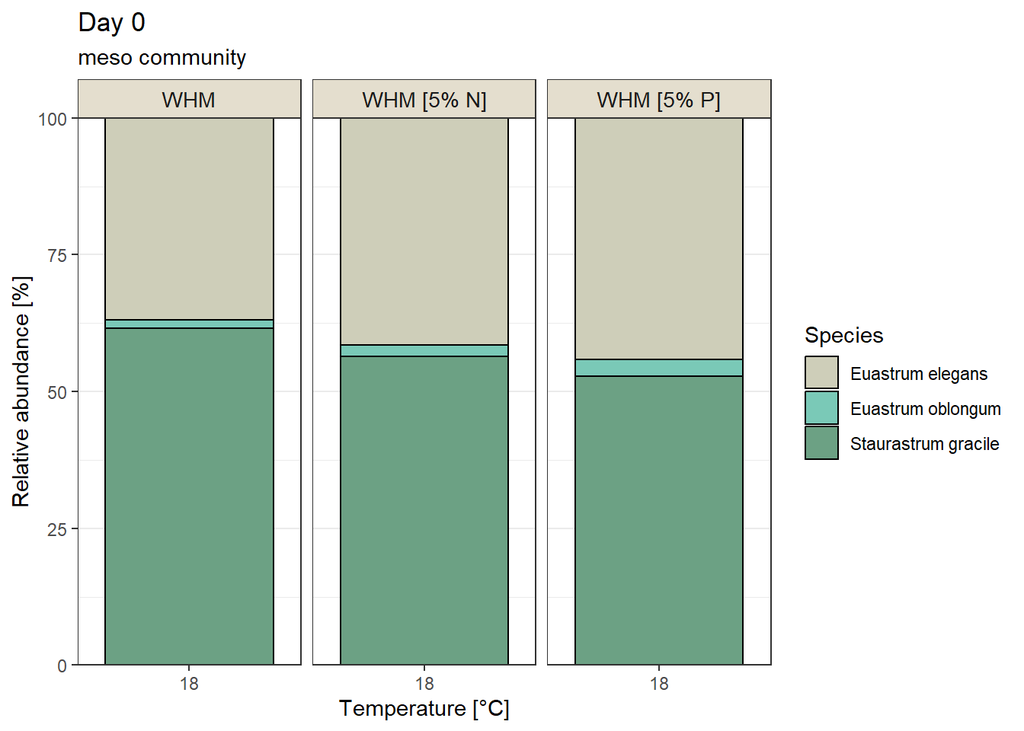

```r
# rel abund
pt0 <- plot_relabund(timestep_day = 0, comm = "meso", palette = "lake") #+
  # theme(legend.position="left",
  #       legend.text = element_text(size=6)) #c(.5,0))
pt0
```

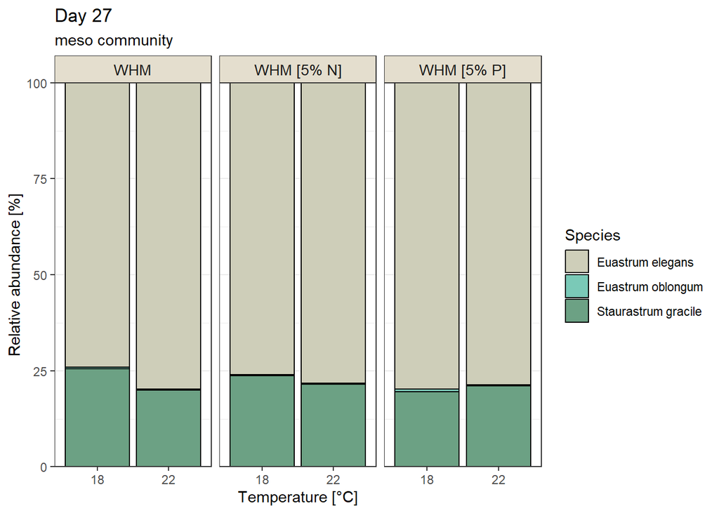

```r
pt27 <- plot_relabund(timestep_day = 27, comm = "meso", palette = "lake") #+
  # theme(legend.position = "none")
pt27
```

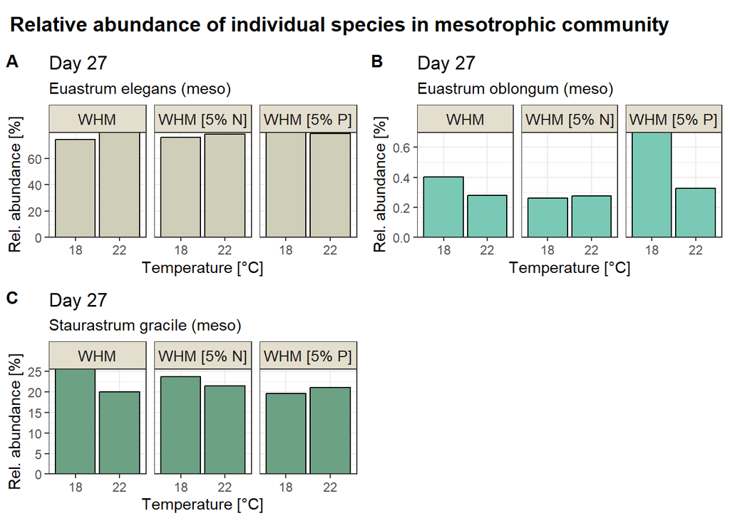

```r
p1 <- dat4plots %>%
    group_by(day_txt, community, media, temp, species, rel_abund) %>%
    distinct(rel_abund, .keep_all = T) %>%
    ungroup() %>%
    filter(day == 27,
           species == "e_elegans") %>% # add in later filter == community
    # plot
    ggplot(aes(fill=species_txt, y=rel_abund, x=as.factor(temp))) +
    geom_bar(colour="black", position="stack", stat="identity") +
    facet_wrap(~media_txt) + #, nrow = 2, ncol = 3
    scale_fill_manual(values = "#CECEB9") + #cal_palette("lake")
    ylab("Rel. abundance [%]") +
    xlab("Temperature [°C]") +
    labs(fill = "Species",
         # change here the community with func argument
         title = paste("Day", 27),
         subtitle = "Euastrum elegans (meso)") +
    scale_y_continuous(expand = c(0,0)) +
    theme_bw() +
    # Customize facet labels
    theme(strip.background = element_rect(fill="#E4DECE"),
          strip.text.x = element_text(size = 10.5),
          legend.position = "none")

p2<- dat4plots %>%
    group_by(day_txt, community, media, temp, species, rel_abund) %>%
    distinct(rel_abund, .keep_all = T) %>%
    ungroup() %>%
    filter(day == 27,
           species == "e_oblongum") %>% # add in later filter == community
    # plot
    ggplot(aes(fill=species_txt, y=rel_abund, x=as.factor(temp))) +
    geom_bar(colour="black", position="stack", stat="identity") +
    facet_wrap(~media_txt) + #, nrow = 2, ncol = 3
    scale_fill_manual(values = "#7AC9B7") + #cal_palette("lake")
    ylab("Rel. abundance [%]") +
    xlab("Temperature [°C]") +
    labs(fill = "Species",
         # change here the community with func argument
         title = paste("Day", 27),
         subtitle = "Euastrum oblongum (meso)") +
    scale_y_continuous(expand = c(0,0)) +
    theme_bw() +
    # Customize facet labels
    theme(strip.background = element_rect(fill="#E4DECE"),
          strip.text.x = element_text(size = 10.5),
          legend.position = "none")

p3 <- dat4plots %>%
    group_by(day_txt, community, media, temp, species, rel_abund) %>%
    distinct(rel_abund, .keep_all = T) %>%
    ungroup() %>%
    filter(day == 27,
           species == "s_gracile") %>% # add in later filter == community
    # plot
    ggplot(aes(fill=species_txt, y=rel_abund, x=as.factor(temp))) +
    geom_bar(colour="black", position="stack", stat="identity") +
    facet_wrap(~media_txt) + #, nrow = 2, ncol = 3
    scale_fill_manual(values = "#6CA184") + #cal_palette("lake")
    ylab("Rel. abundance [%]") +
    xlab("Temperature [°C]") +
    labs(fill = "Species",
         # change here the community with func argument
         title = paste("Day", 27),
         subtitle = "Staurastrum gracile (meso)") +
    scale_y_continuous(expand = c(0,0)) +
    theme_bw() +
    # Customize facet labels
    theme(strip.background = element_rect(fill="#E4DECE"),
          strip.text.x = element_text(size = 10.5),
          legend.position = "none")

btmrow <- plot_grid(p1, p2, p3, labels = c('A', 'B', 'C'), label_size = 12, ncol = 2)

# now add the title
title <- ggdraw() +
  draw_label(
    "Relative abundance of individual species in mesotrophic community",
    fontface = 'bold',
    x = 0,
    hjust = 0
  ) +
  theme(
    # add margin on the left of the drawing canvas,
    # so title is aligned with left edge of first plot
    plot.margin = margin(0, 0, 0, 7)
  )

plot_grid(
  title, btmrow,
  ncol = 1,
  # rel_heights values control vertical title margins
  rel_heights = c(0.1, 1)
)
```

### 1.2.2 ANOVA

*Question: Is the relative abundance of each species significantly affected by temperature? Nutrients?*

```r
# ANOVA for each species
for (i in 1:3) {

dat4aov <- flowcam_dat1 %>%
  filter(day == 27,
         species %in% species_list[i]) %>% #
  select(rel_abund, temp, media)

model <- lm(rel_abund ~ temp + media, dat = dat4aov)

print("------------------------------------------------------------")
print(species_list[[i]])


aov <- aov(model)
print(summary(aov))

post_hoc <- TukeyHSD(aov)
print(post_hoc)


}
```

```
## [1] "------------------------------------------------------------"
## [1] "s_gracile"
##             Df Sum Sq Mean Sq F value Pr(>F)
## temp         1  20.21  20.207   7.550 0.0157 *
## media        2  22.45  11.226   4.194 0.0374 *
## Residuals   14  37.47   2.677
## ---
## Signif. codes:  0 '***' 0.001 '**' 0.01 '*' 0.05 '.' 0.1 ' ' 1
##   Tukey multiple comparisons of means
##     95% family-wise confidence level
##
## Fit: aov(formula = model)
##
## $temp
##            diff       lwr        upr    p adj
## 22-18 -2.119083 -3.773209 -0.4649563 0.015717
##
## $media
##              diff         lwr       upr     p adj
## 5P-5N  -2.2789913 -4.75117387 0.1931912 0.0726632
## WHM-5N  0.1710815 -2.30110104 2.6432640 0.9821003
## WHM-5P  2.4500728 -0.02210971 4.9222554 0.0522110
##
## [1] "------------------------------------------------------------"
## [1] "e_elegans"
##             Df Sum Sq Mean Sq F value  Pr(>F)
## temp         1  23.38  23.385   9.398 0.00838 **
## media        2  18.76   9.378   3.769 0.04903 *
## Residuals   14  34.83   2.488
## ---
## Signif. codes:  0 '***' 0.001 '**' 0.01 '*' 0.05 '.' 0.1 ' ' 1
##   Tukey multiple comparisons of means
##     95% family-wise confidence level
##
## Fit: aov(formula = model)
##
## $temp
##           diff       lwr     upr     p adj
## 22-18 2.279601 0.6847718 3.87443 0.0083845
##
```

[output cut: 13 more lines]

```
## Signif. codes:  0 '***' 0.001 '**' 0.01 '*' 0.05 '.' 0.1 ' ' 1
##   Tukey multiple comparisons of means
##     95% family-wise confidence level
##
## Fit: aov(formula = model)
##
## $temp
##             diff        lwr         upr     p adj
## 22-18 -0.1605179 -0.2530164 -0.06801938 0.0022762
##
## $media
##               diff         lwr         upr     p adj
## 5P-5N   0.24566387  0.10741983  0.38390791 0.0010209
## WHM-5N  0.07248617 -0.06575787  0.21073021 0.3811072
## WHM-5P -0.17317770 -0.31142174 -0.03493366 0.0142302
```

# 2 Meso-oligo community

## 2.1 ANOVA

### 2.1.1 Maximum growth rate

**Click for details on tidying data.**

```r
dat_mo <- growth_params_lag %>%
  filter(community == "meso-oligo") %>%
  select(mumax, Temp, Nutrient)
glimpse(dat_mo) # response variable = mumax; explanatory variable = temperature / nutrient
```

```
## Rows: 18
## Columns: 3
## $ mumax    <dbl> 0.24133847, 0.10802236, 0.16473668, 0.08583002, 0.17038186, 0…
## $ Temp     <chr> "18", "18", "18", "22", "22", "22", "18", "18", "18", "22", "…
## $ Nutrient <chr> "WHM", "WHM", "WHM", "WHM", "WHM", "WHM", "WHM_5N", "WHM_5N",…
```

```r
#### Convert Temperature + Nutrient treatments to factors (ANOVA test likes it in this format)
dat_mo$Temp <- as.factor(dat_mo$Temp)
dat_mo$Nutrient <- as.factor(dat_mo$Nutrient)
#### Sanity check
table(dat_mo$Temp, dat_mo$Nutrient)
```

```
##
##      WHM WHM_5N WHM_5P
##   18   3      3      3
##   22   3      3      3
```

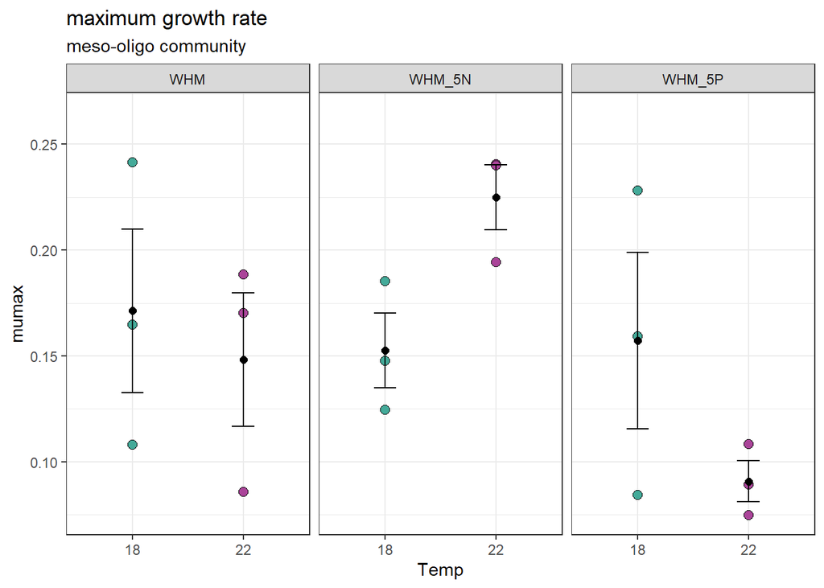

```r
growth_params_lag %>%
  filter(community == "meso-oligo") %>%
ggplot(aes(x = Temp, y = mumax, color = Temp)) +
  geom_point(size=2.5, aes(fill=Temp), color = "black", pch = 21)+
  stat_summary(fun=mean,
               geom="point",
               show.legend = T,
               cex=2, color="black")+
  stat_summary(fun.data=mean_se,
               geom="errorbar",
               show.legend = F,
               width=0.2,
               cex=0.5, color="black")+
  scale_fill_manual(values = c("#44AA99", "#AA4499")) +
  facet_wrap(.~Nutrient) +
  ylim(NA, 0.265) +
  labs(title="maximum growth rate",
       subtitle="meso-oligo community",
       cex=1)+
  theme_bw() +
  theme(legend.position = "none")
```

**Click for details on model fitting, AICc test, and anova assumptions.**

**Fit model**

```r
# Additive model
mo_model_add <- lm(mumax ~ Temp + Nutrient, data = dat_mo)
mo_model_add
```

```
##
## Call:
## lm(formula = mumax ~ Temp + Nutrient, data = dat_mo)
##
## Coefficients:
##    (Intercept)          Temp22  NutrientWHM_5N  NutrientWHM_5P
##       0.162653       -0.005705        0.028941       -0.035799
```

```r
# Interactive model
mo_model_interx <- lm(mumax ~ Temp*Nutrient, data = dat_mo)
mo_model_interx
```

```
##
## Call:
## lm(formula = mumax ~ Temp * Nutrient, data = dat_mo)
##
## Coefficients:
##           (Intercept)                 Temp22         NutrientWHM_5N
##               0.17137               -0.02313               -0.01887
##        NutrientWHM_5P  Temp22:NutrientWHM_5N  Temp22:NutrientWHM_5P
##              -0.01413                0.09563               -0.04335
```

**Test AICc**

```r
models <- list(mo_model_add, mo_model_interx)
model.names <- c("mo_model_add", "mo_model_interx")

aictab(cand.set = models, modnames = model.names)
```

```
##
## Model selection based on AICc:
##
##                 K   AICc Delta_AICc AICcWt Cum.Wt    LL
## mo_model_add    5 -42.03       0.00   0.79   0.79 28.51
## mo_model_interx 7 -39.36       2.67   0.21   1.00 32.28
```

*Based on AICc test, the additive model is a better fit.*

**Check assumptions of interactive model**

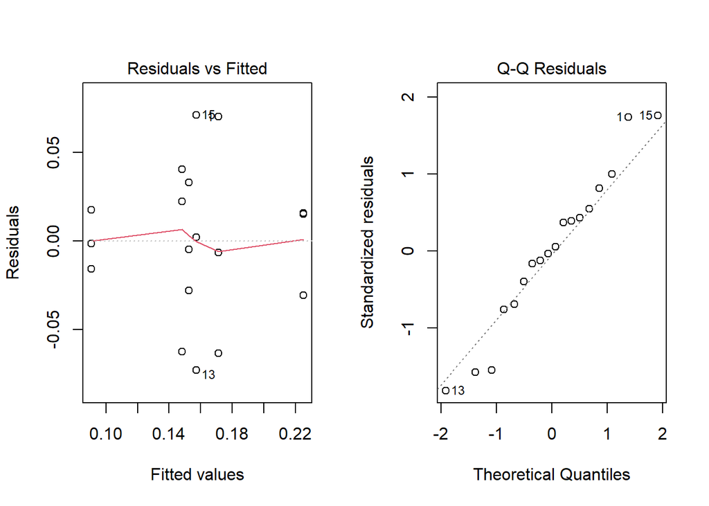

```r
# Normality
OP <- par(mfrow=c(1,2))
plot(mo_model_interx, 1:2)
```

```r
par(OP)

# Homogeneity of Variance
leveneTest(mumax~Temp*Nutrient, data = dat_mo)
```

```
## Levene's Test for Homogeneity of Variance (center = median)
##       Df F value Pr(>F)
## group  5  0.6753 0.6503
##       12
```

*Data meets assumptions for the most part.*

#### 2.1.1.1 Run Interactive ANOVA

```r
aov_interx <- aov(mo_model_interx)
summary(aov_interx)
```

```
##               Df   Sum Sq  Mean Sq F value Pr(>F)
## Temp           1 0.000146 0.000146   0.060 0.8103
## Nutrient       2 0.012621 0.006311   2.595 0.1157
## Temp:Nutrient  2 0.015169 0.007584   3.119 0.0811 .
## Residuals     12 0.029181 0.002432
## ---
## Signif. codes:  0 '***' 0.001 '**' 0.01 '*' 0.05 '.' 0.1 ' ' 1
```

#### 2.1.1.2 Tukey’s HSD post-hoc test

```r
TukeyHSD(aov_interx)
```

```
##   Tukey multiple comparisons of means
##     95% family-wise confidence level
##
## Fit: aov(formula = mo_model_interx)
##
## $Temp
##              diff         lwr        upr     p adj
## 22-18 -0.00570501 -0.05635461 0.04494459 0.8102824
##
## $Nutrient
##                      diff         lwr        upr     p adj
## WHM_5N-WHM     0.02894133 -0.04701524 0.10489791 0.5809690
## WHM_5P-WHM    -0.03579949 -0.11175606 0.04015709 0.4442497
## WHM_5P-WHM_5N -0.06474082 -0.14069740 0.01121576 0.0985994
##
## $`Temp:Nutrient`
##                             diff         lwr         upr     p adj
## 22:WHM-18:WHM       -0.023131455 -0.15837500 0.112112086 0.9909620
## 18:WHM_5N-18:WHM    -0.018872304 -0.15411584 0.116371237 0.9964526
## 22:WHM_5N-18:WHM     0.053623518 -0.08162002 0.188867059 0.7633872
## 18:WHM_5P-18:WHM    -0.014125516 -0.14936906 0.121118025 0.9991031
## 22:WHM_5P-18:WHM    -0.080604912 -0.21584845 0.054638629 0.3945519
## 18:WHM_5N-22:WHM     0.004259151 -0.13098439 0.139502692 0.9999976
## 22:WHM_5N-22:WHM     0.076754973 -0.05848857 0.211998514 0.4430048
## 18:WHM_5P-22:WHM     0.009005939 -0.12623760 0.144249480 0.9999000
## 22:WHM_5P-22:WHM    -0.057473457 -0.19271700 0.077770084 0.7115996
## 22:WHM_5N-18:WHM_5N  0.072495822 -0.06274772 0.207739363 0.4998246
## 18:WHM_5P-18:WHM_5N  0.004746788 -0.13049675 0.139990329 0.9999958
## 22:WHM_5P-18:WHM_5N -0.061732608 -0.19697615 0.073510933 0.6518066
## 18:WHM_5P-22:WHM_5N -0.067749034 -0.20299258 0.067494507 0.5660510
## 22:WHM_5P-22:WHM_5N -0.134228430 -0.26947197 0.001015111 0.0521548
## 22:WHM_5P-18:WHM_5P -0.066479396 -0.20172294 0.068764145 0.5840879
```

### 2.1.2 Results

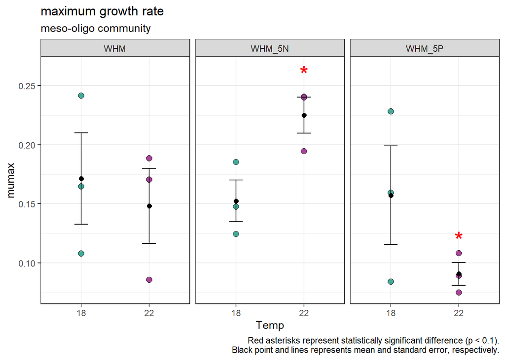

```r
# Plot
dat_text <- data.frame(Temp = c("22", "22"),
            mumax = c(0.26, 0.12),
            lab = c("*", "*"),
            Nutrient = factor(c("WHM_5N", "WHM_5P"),levels = c("WHM","WHM_5N", "WHM_5P")))

growth_params_lag %>%
  filter(community == "meso-oligo") %>%
ggplot(aes(x = Temp, y = mumax, color = Temp)) +
  geom_point(size=2.5, aes(fill=Temp), color = "black", pch = 21)+
  stat_summary(fun=mean,
               geom="point",
               show.legend = T,
               cex=2, color="black")+
  stat_summary(fun.data=mean_se,
               geom="errorbar",
               show.legend = F,
               width=0.2,
               cex=0.5, color="black")+
  scale_fill_manual(values = c("#44AA99", "#AA4499")) +
  facet_wrap(.~Nutrient) +
  geom_text(data = dat_text, label = c("*", "*"), size = 8, color = "red") +
  ylim(NA, 0.265) +
  labs(title="maximum growth rate",
       subtitle="meso-oligo community",
       caption = "Red asterisks represent statistically significant difference (p < 0.1).\nBlack point and lines represents mean and standard error, respectively.",
       cex=1)+
  theme_bw() +
  theme(legend.position = "none")
```

Temp and nutrients do not have a significant main effect on mumax; however, there is a significant interactive effect between them  
(p = 0.08). Tukey’s HSD post-hoc test revealed that the mumax was significantly different between the N-limited and P-limited groups in warmer temperatures (22°C, p = 0.05). All other groups experienced no statistically significant differences.

## 2.2 Community relative abundance

*Question: How does relative abundance change over time? Under nutrient-limitation? In a warmer temperature?*

### 2.2.1 Plots

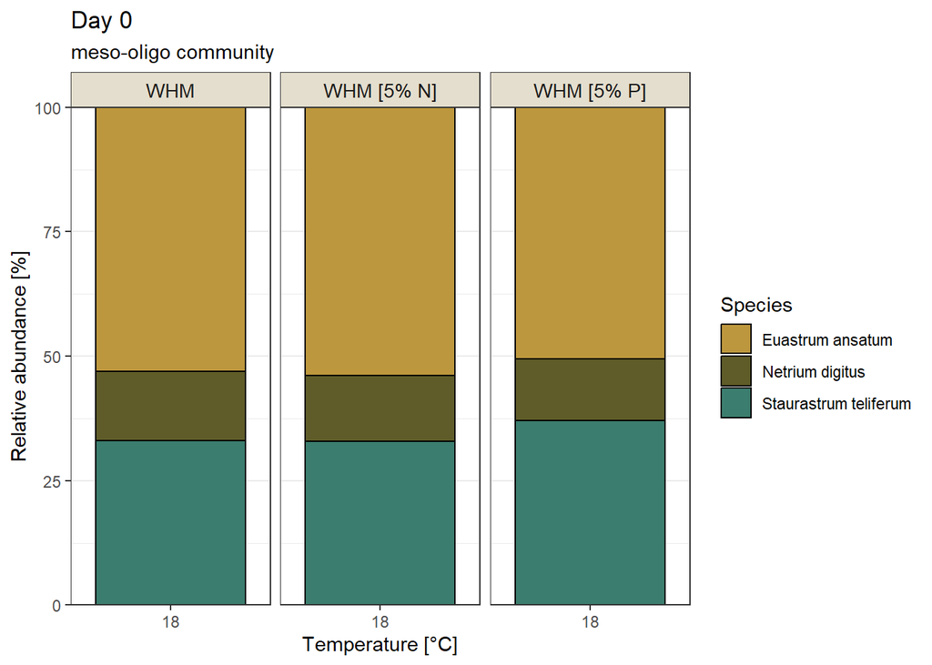

```r
# rel abund
pt0 <- plot_relabund(timestep_day = 0, comm = "meso-oligo", palette = "sierra1") #+
  # theme(legend.position="left",
  #       legend.text = element_text(size=6)) #c(.5,0))
pt0
```

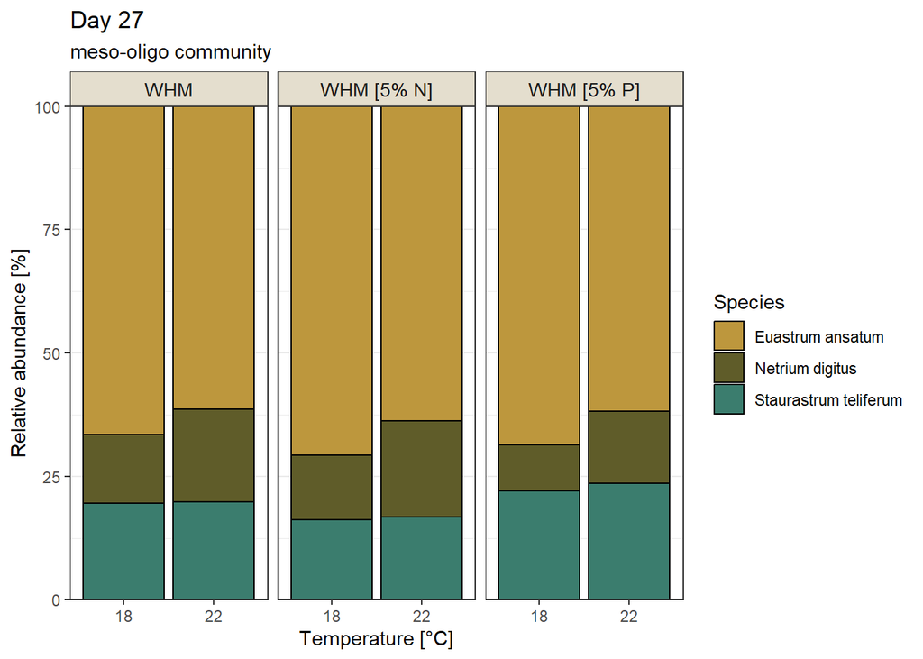

```r
pt27 <- plot_relabund(timestep_day = 27, comm = "meso-oligo", palette = "sierra1") #+
  # theme(legend.position = "none")
pt27
```

### 2.2.2 ANOVA

```r
# ANOVA for each species
for (i in 4:6) {

dat4aov <- flowcam_dat1 %>%
  filter(day == 27,
         species %in% species_list[i]) %>% #
  select(rel_abund, temp, media)

model <- lm(rel_abund ~ temp + media, dat = dat4aov)

print("------------------------------------------------------------")
print(species_list[[i]])


aov <- aov(model)
print(summary(aov))

post_hoc <- TukeyHSD(aov)
print(post_hoc)


}
```

```
## [1] "------------------------------------------------------------"
## [1] "e_ansatum"
##             Df Sum Sq Mean Sq F value   Pr(>F)
## temp         1 179.96  179.96  936.27 3.18e-14 ***
## media        2  32.62   16.31   84.86 1.49e-08 ***
## Residuals   14   2.69    0.19
## ---
## Signif. codes:  0 '***' 0.001 '**' 0.01 '*' 0.05 '.' 0.1 ' ' 1
##   Tukey multiple comparisons of means
##     95% family-wise confidence level
##
## Fit: aov(formula = model)
##
## $temp
##            diff       lwr       upr p adj
## 22-18 -6.323904 -6.767174 -5.880633     0
##
## $media
##             diff       lwr        upr     p adj
## 5P-5N  -2.022415 -2.684907 -1.3599226 0.0000039
## WHM-5N -3.266778 -3.929270 -2.6042857 0.0000000
## WHM-5P -1.244363 -1.906855 -0.5818711 0.0006235
##
## [1] "------------------------------------------------------------"
## [1] "s_teliferum"
##             Df Sum Sq Mean Sq F value   Pr(>F)
## temp         1   2.66    2.66   29.61 8.68e-05 ***
## media        2 120.05   60.03  667.23 1.30e-14 ***
## Residuals   14   1.26    0.09
## ---
## Signif. codes:  0 '***' 0.001 '**' 0.01 '*' 0.05 '.' 0.1 ' ' 1
##   Tukey multiple comparisons of means
##     95% family-wise confidence level
##
## Fit: aov(formula = model)
##
## $temp
##            diff       lwr      upr    p adj
## 22-18 0.7694316 0.4661768 1.072686 8.68e-05
##
```

[output cut: 13 more lines]

```
## Signif. codes:  0 '***' 0.001 '**' 0.01 '*' 0.05 '.' 0.1 ' ' 1
##   Tukey multiple comparisons of means
##     95% family-wise confidence level
##
## Fit: aov(formula = model)
##
## $temp
##           diff      lwr      upr p adj
## 22-18 5.554472 5.213192 5.895752     0
##
## $media
##               diff        lwr        upr   p adj
## 5P-5N  -4.30325730 -4.8133195 -3.7931952 0.00000
## WHM-5N  0.05860058 -0.4514616  0.5686627 0.95155
## WHM-5P  4.36185788  3.8517957  4.8719200 0.00000
```

# 3 Session Info

**Click for details**

#endscript